# Análisis Estadístico Descriptivo e Inferencial del Impacto de Condiciones Climáticas y Prácticas Agrícolas sobre el Calibre de las Paltas Hass

##### 4.2.2.2.8. Variable humedad_promedio

Se obtienen los datos descriptivos más reperesentativos de la variable.

```r
# Datos descriptivos de la variable
summary(reporte$humedad_promedio)
```

```
##    Min. 1st Qu.  Median    Mean 3rd Qu.    Max.
##   64.46   67.06   68.21   70.14   72.56   80.85
```

Se continua con la generación de gráficos.

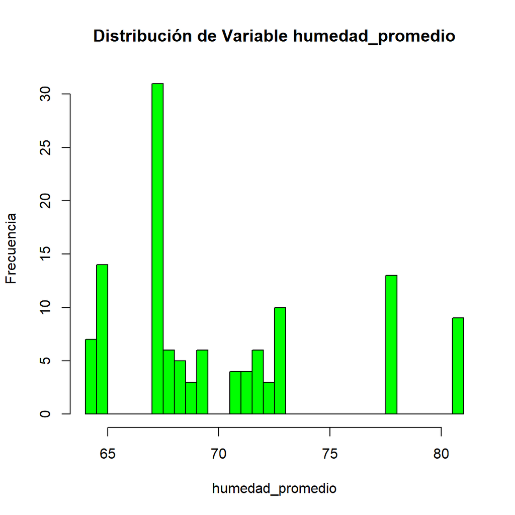

```r
# Histograma para la variable numérica humedad_promedio
hist(reporte$humedad_promedio, main="Distribución de Variable humedad_promedio", xlab="humedad_promedio", ylab="Frecuencia", col="green", breaks=30)
```

**Interpretación**: La distribución de la humedad promedio muestra una concentración significativa de los datos en torno al rango de 65 a 75%, con un pico prominente alrededor del valor 67%. La presencia de barras más pequeñas hacia el extremo derecho indica la presencia de valores más altos pero menos frecuentes.

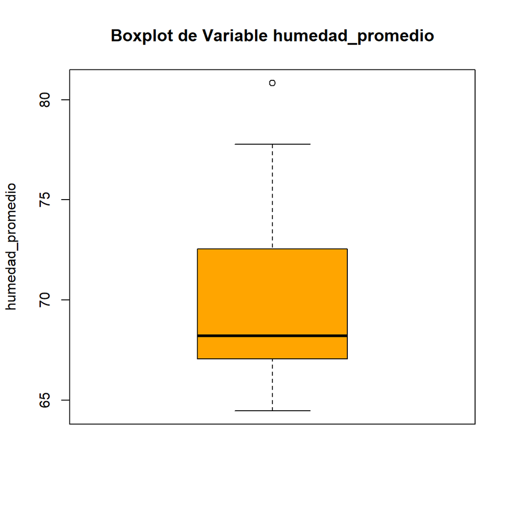

```r
# Boxplot para la variable numérica humedad_promedio
boxplot(reporte$humedad_promedio, main="Boxplot de Variable humedad_promedio", ylab="humedad_promedio", col="orange")
```

**Interpretación**: El boxplot revela que la mediana está cercana al primer cuartil, lo que sugiere una distribución sesgada hacia valores menores. No hay presencia de valores atípicos inferiores y hay algunos valores atípicos superiores, lo que indica que hay algunas observaciones con humedad significativamente más alta que la mayoría de los datos.

##### 4.2.2.2.9. Variable humedad_maxima

Se obtienen los datos descriptivos más reperesentativos de la variable.

```r
# Datos descriptivos de la variable
summary(reporte$humedad_maxima)
```

```
##    Min. 1st Qu.  Median    Mean 3rd Qu.    Max.
##   76.00   84.00   85.00   85.45   87.00   94.00
```

Se continua con la generación de gráficos.

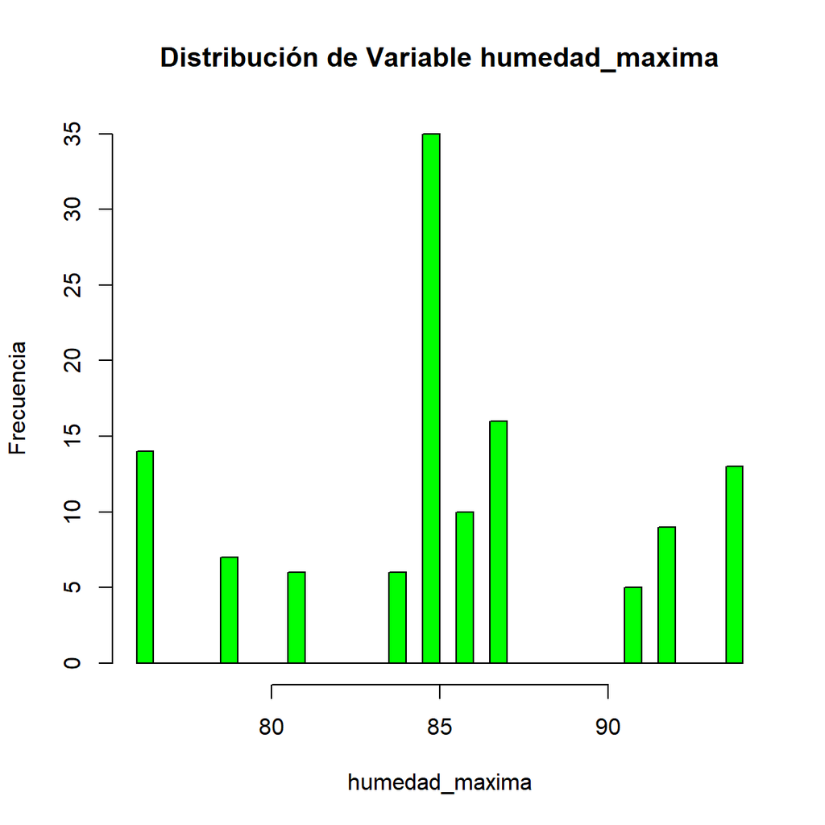

```r
# Histograma para la variable numérica humedad_maxima
hist(reporte$humedad_maxima, main="Distribución de Variable humedad_maxima", xlab="humedad_maxima", ylab="Frecuencia", col="green", breaks=30)
```

**Interpretación**: La distribución de la humedad_maxima muestra una concentración de datos en torno al rango de 80 a 90%, lo que se refleja en las barras altas alrededor de estos valores. Existe una frecuencia notablemente alta cerca del valor de la mediana de 85%, indicando que una gran cantidad de observaciones se agrupa en esta área. La distribución parece sesgada hacia la izquierda, con menos frecuencias en los valores más altos de humedad máxima, superiores al tercer cuartil de 87%.

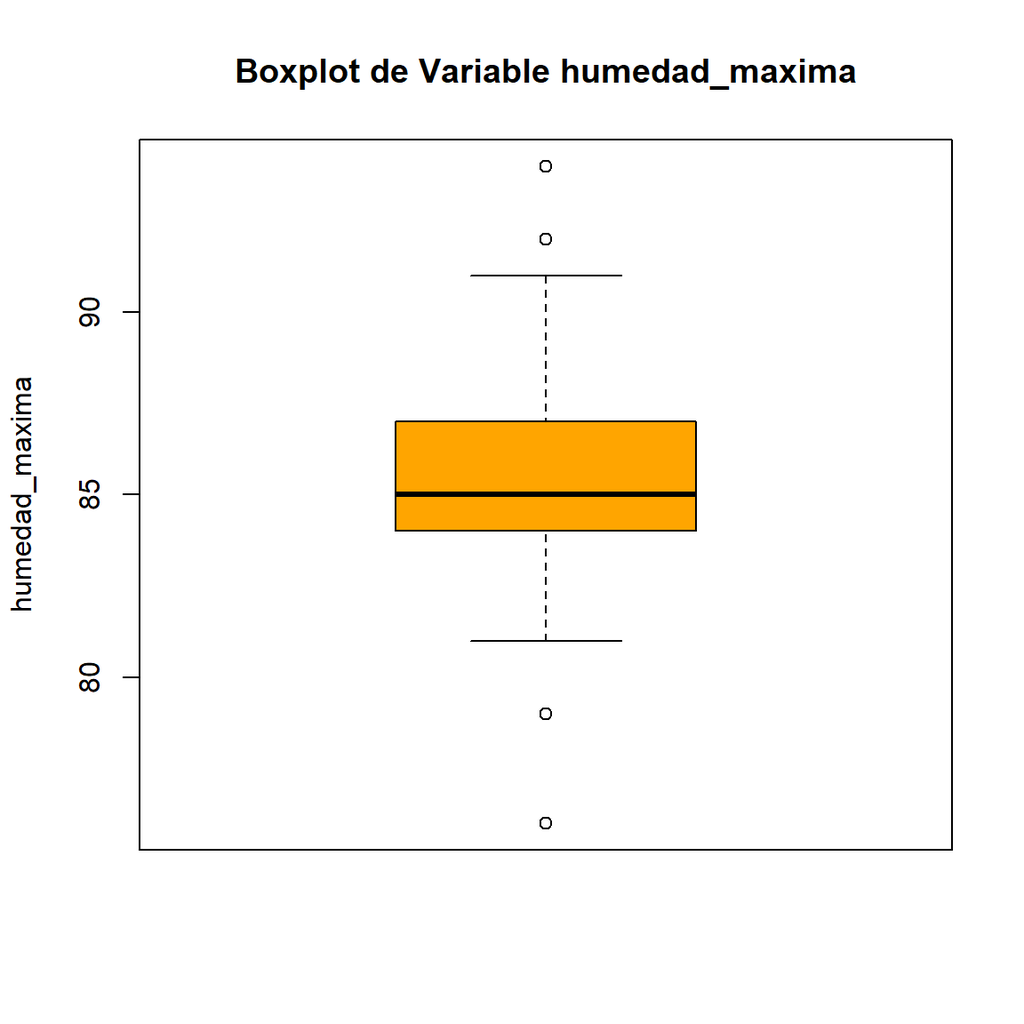

```r
# Boxplot para la variable numérica humedad_maxima
boxplot(reporte$humedad_maxima, main="Boxplot de Variable humedad_maxima", ylab="humedad_maxima", col="orange")
```

##### 4.2.2.2.10. Variable humedad_minima

Se obtienen los datos descriptivos más reperesentativos de la variable.

```r
# Datos descriptivos de la variable
summary(reporte$humedad_minima)
```

```
##    Min. 1st Qu.  Median    Mean 3rd Qu.    Max.
##   36.00   41.00   45.00   45.93   48.00   62.00
```

Se continua con la generación de gráficos.

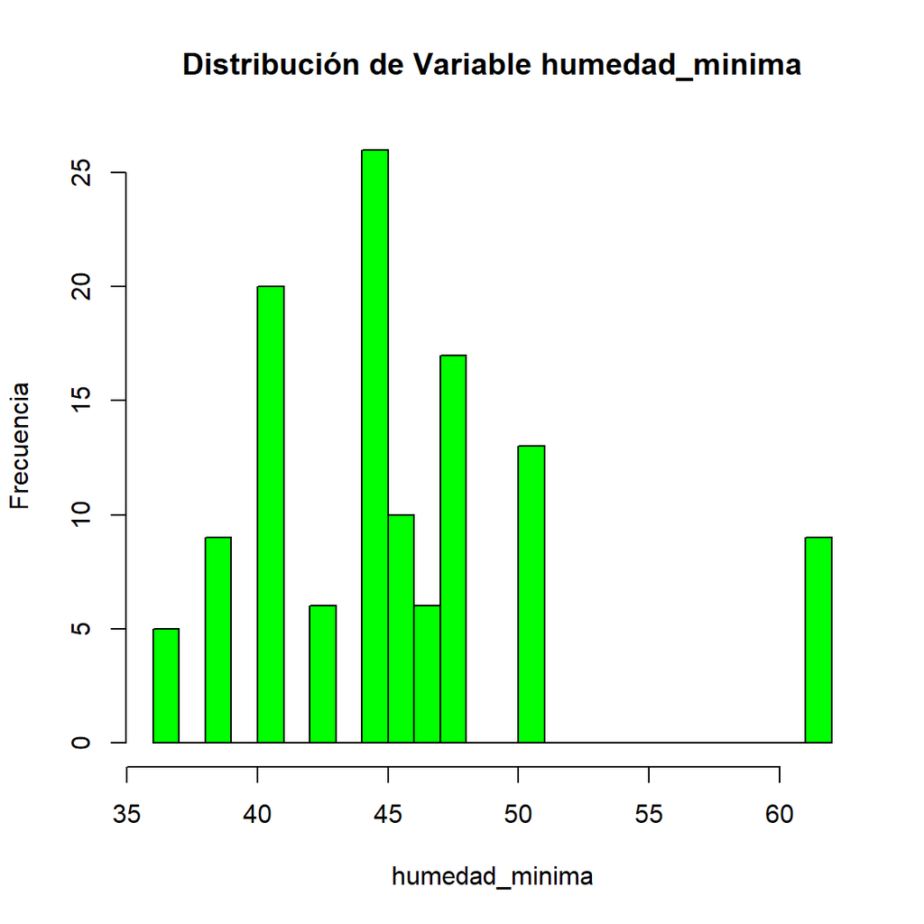

```r
# Histograma para la variable numérica humedad_minima
hist(reporte$humedad_minima, main="Distribución de Variable humedad_minima", xlab="humedad_minima", ylab="Frecuencia", col="green", breaks=30)
```

**Interpretación**: Muestra una distribución con una tendencia hacia los valores más bajos de humedad, con la mayor frecuencia de datos entre 40 y 50%, lo cual es consistente con la mediana de 45%. Hay menos frecuencia conforme la humedad disminuye por debajo de 40% o aumenta por encima de 50%, lo que sugiere una concentración de los datos en torno a los valores intermedios de humedad.

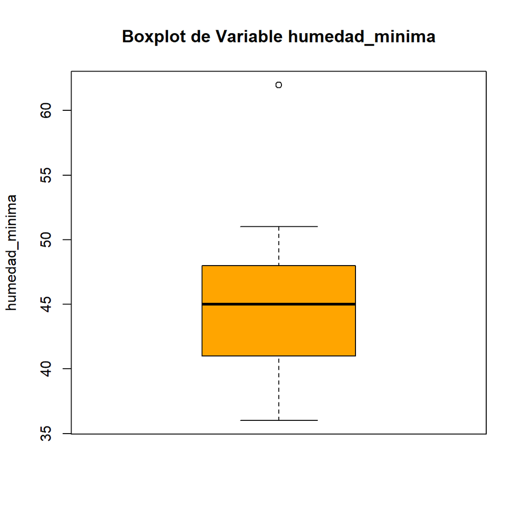

```r
# Boxplot para la variable numérica humedad_minima
boxplot(reporte$humedad_minima, main="Boxplot de Variable humedad_minima", ylab="humedad_minima", col="orange")
```